# HW4

Avinash Ramu

October 2, 2016

## 13.2

```
Models for adjusting individual ratings: a committee of 10 persons is evaluating
100 job applications. Each person on the committee reads 30 applications
(structured so that each application is read by three people) and gives each a
numerical rating between 1 and 10.
(a) It would be natural to rate the applications based on their combined scores;
however, there is a worry that different raters use different standards, and we
would like to correct for this. Set up a model for the ratings (with parameters
for the applicants and the raters).
(b) It is possible that some persons on the committee show more variation than
others in their ratings. Expand your model to allow for this.
```

### A

$$rating = \beta_0 + \beta_1 applicant + \beta_1 x_1 + \beta_2 x_2 + \beta_3 x_3 + .... + \beta_{10} x_{10}$$

x_1, x_2 .. x_10 are set to 0/1 depending on if committee_member1, 2 .. 10 are involved. Every individual gets his/her own coefficient, this could be combined into the intercept if each individual is rated only once it could reflect the mean score for that individual.

### B

$$rating = \beta_0 + \beta_1 applicant + \beta_{j1[i]} x_1 + \beta_{j2[i]} x_2 + \beta_{j3[i]} x_3$$

Here J1, J2 and J3 are the coefficients for the first, second and third committee member. Each committee member has a group consisting of all his scores. The variance of each commitee member is reflected in his/her group scores.

## 13.4

```
Models with unequal variances: the folder age.guessing contains a dataset from
Gelman and Nolan (2002) from a classroom demonstration in which 10 groups
of students guess the ages of 10 different persons based on photographs. The
dataset also includes the true ages of the people in the photographs.
Set up a non-nested model to these data, including a coefficient for each of the
persons in the photos (indicating their apparent age), a coefficient for each of
the 10 groups (indicating potential systematic patterns of groups guessing high
or low), and a separate error variance for each group (so that some groups are
more consistent than others).
```

```r
age <- read.table("age.guessing.transformed.csv", head = T, sep = "\t")
head(age)
```

```
##    y group person true.age
## 1 14     1      1       29
## 2 -6     1      2       30
## 3  5     1      3       14
## 4 19     1      4       42
## 5  0     1      5       37
## 6 -5     1      6       57
```

```r
lmer1 <- lmer(y ~ 1 +  (1 | person) + (1 | group), data = age)
display(lmer1)
```

```
## lmer(formula = y ~ 1 + (1 | person) + (1 | group), data = age)
## coef.est  coef.se
##    -0.65     2.05
##
## Error terms:
##  Groups   Name        Std.Dev.
##  person   (Intercept) 6.39
##  group    (Intercept) 0.00
##  Residual             3.72
## ---
## number of obs: 100, groups: person, 10; group, 10
## AIC = 584.2, DIC = 582.7
## deviance = 579.5
```

Grouping by person explains a std-dev of 6.39 while grouping by the group explains a variance of zero and hence can be removed. There does not appear to be a group specific pattern of guessing.

## 13.5

```
Return to the CD4 data introduced from Exercise 11.4.
(a) Extend the model in Exercise 12.2 to allow for varying slopes for the time
predictor.
(b) Next fit a model that does not allow for varying slopes but does allow for
different coefficients for each time point (rather than fitting the linear trend).
(c) Compare the results of these models both numerically and graphically.
```

### A

$$\sqrt{CD4PCT} = \beta_0 + \beta_1 time + \beta_{j1[i]} time + \beta_{j2[i]} treatment + \beta_{j3[i]} baseage$$

```r
cd4 <- read.table("../hw3/dat/allvar.csv", head = T, sep = ",")
cd4$time <- cd4$visage - cd4$baseage
lmer2 <- lmer(sqrt(CD4PCT) ~ time + (time + treatmnt + baseage | newpid), data = cd4)
display(lmer2)
```

```
## lmer(formula = sqrt(CD4PCT) ~ time + (time + treatmnt + baseage |
##     newpid), data = cd4)
##             coef.est coef.se
## (Intercept)  4.85     0.09
## time        -0.37     0.07
##
## Error terms:
##  Groups   Name        Std.Dev. Corr
##  newpid   (Intercept) 1.93
##           time        0.58     -0.11
##           treatmnt    0.47     -0.91  0.48
##           baseage     0.26     -0.48 -0.16  0.49
##  Residual             0.72
## ---
## number of obs: 1072, groups: newpid, 250
## AIC = 3127.4, DIC = 3088.2
## deviance = 3094.8
```

```r
a_hat_lmer2 <- fixef(lmer2)[1]  + ranef(lmer2)$newpid[1] + ranef(lmer2)$newpid[2]*cd4$time + ranef(lmer2)$newpid[3] * cd4$treatmnt + ranef(lmer2)$newpid[4] * cd4$baseage
b_hat_lmer2 <- fixef(lmer2)[2]
```

### B

$$\sqrt{CD4PCT} = \beta_0 + \beta_1 time + \beta_{j1[i]} treatment + \beta_{j2[i]} baseage$$

```r
#Make time a factor here:
cd4$newtime <- as.factor(round(cd4$time, 1))
lmer3 <- lmer(sqrt(CD4PCT) ~ newtime + (treatmnt + baseage | newpid), data=cd4)
display(lmer3)
```

```
## lmer(formula = sqrt(CD4PCT) ~ newtime + (treatmnt + baseage |
##     newpid), data = cd4)
##             coef.est coef.se
## (Intercept)  4.86     0.10
## newtime0.2  -0.14     0.09
## newtime0.3   0.02     0.16
## newtime0.4  -0.11     0.29
## newtime0.5  -0.20     0.09
## newtime0.6  -0.15     0.27
## newtime0.7  -0.30     0.09
## newtime0.8  -0.35     0.18
## newtime0.9  -0.25     0.11
## newtime1    -0.46     0.13
## newtime1.1  -0.38     0.17
## newtime1.2  -0.50     0.11
## newtime1.3  -0.55     0.25
## newtime1.4  -0.56     0.12
## newtime1.5  -0.48     0.16
## newtime1.6   0.20     0.43
## newtime1.7  -0.49     0.61
## newtime1.8   0.12     0.85
## newtime1.9  -0.84     0.50
##
## Error terms:
##  Groups   Name        Std.Dev. Corr
##  newpid   (Intercept) 1.78
##           treatmnt    0.28     -1.00
##           baseage     0.25     -0.40  0.40
##  Residual             0.78
## ---
## number of obs: 1072, groups: newpid, 250
## AIC = 3199.8, DIC = 3087.5
## deviance = 3117.6
```

### C

In the model 13.5A the coefficients for time are significant in the fixed effects indicating a decrease in CD4PCT with time. At the group level, time treatment and age contribute towards explaining the residual variance.

In the model 13.5B, in the fixed effects the coefficients of time are not significant sometimes and significant sometimes probably reflecting the number of samples at these time points. At the group level, treatment and age contribute towards explaining the residual variance and should be retained at the group level.

Plotting the results of the models for a sample of 8 patients.

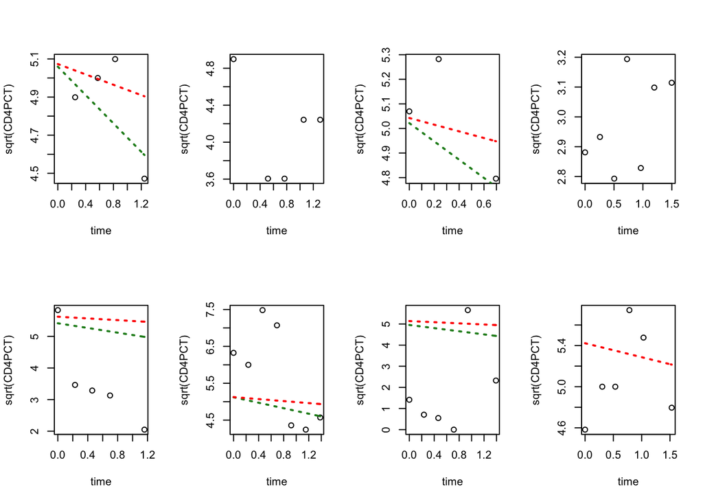

```r
a_hat_lmer3 <- fixef(lmer3)[1]  + ranef(lmer3)$newpid[1] + ranef(lmer3)$newpid[2] * cd4$treatmnt + ranef(lmer3)$newpid[3] * cd4$baseage
b_hat_lmer3 <- fixef(lmer3)[2]

subset_index <- sample(cd4$newpid, 8, replace=F)
par(mfrow = c(2, 4))
for (j in subset_index){
  cd4_subset = cd4[cd4$newpid == j, ]
  plot(cd4_subset$time, sqrt(cd4_subset$CD4PCT), xlab = "time", ylab = "sqrt(CD4PCT)")
  curve(a_hat_lmer2[j,] + b_hat_lmer2*x, lty=3, lwd=2, col="forestgreen", add=TRUE)
  curve(a_hat_lmer3[j,] + b_hat_lmer3*x, lty=3, lwd=2, col="red", add=TRUE)
}
```